# ExpoMet R package demonstration using an untargeted metabolomics dataset

Maya Arnott

September 29th, 2026

# Load Packages

```r
library(ExpoMet)
library(ggplot2)
```

In this document, we illustrate the main features of the `ExpoMet` R package through a worked example. The package aims to provide a complete toolkit for conducting exposome-wide association studies (ExWAS) and metabolome-wide association studies (MWAS), integrating quality control, preprocessing, feature filtering, data transformation, association analyses, visualization, and reproducible reporting. ExpoMet is designed to be accessible to both trainees and experienced investigators. ExWAS and MWAS both test the association between a large number of chemical features and a health outcome individually. The intended package workflow of analyzing high-dimensional data is demonstrated in the diagram below.

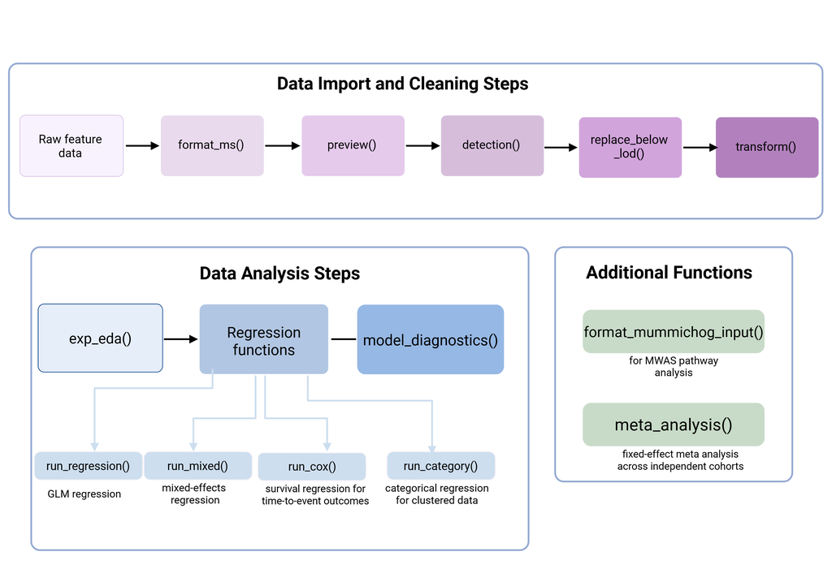

# Overview of ExpoMet

MWAS is an approach to studying the relationship between many metabolites and health outcomes. ExWAS studies the relationship between many external/internal environmental factors and health outcomes. Rather than testing a single pre-specified feature, MWAS and ExWAS test each measured feature individually against the same outcome. The framework is flexible in its orientation. The health outcome can appear on the left-hand side or the right-hand side of the formula:

$$g(\mu_{ij}) = \beta_{0j} + \beta_j x_{ij} + \boldsymbol{\gamma}^T_j
\mathbf{c}_i, \quad
j = 1, \ldots, p, \quad
\mu_{ij} = E(Y_i)$$

$$g(\nu_{ij}) = \beta_{0j} + \beta_j y_{i} + \boldsymbol{\gamma}^T_j
\mathbf{c}_i, \quad
j = 1, \ldots, p, \quad
\nu_{ij} = E(X_{ij})$$

where $g$ is a monotonic link function; $\mu_{ij}$ is the expected outcome and $\nu_{ij}$ is the expected feature level $j$, each conditional on the predictors; $\beta_j$ is the coefficient of interest for feature $j$; $x_{ij}$ is the measured level of feature $j$ for participant $i$; and $\mathbf{c}_i$ is a vector of covariates with coefficients $\boldsymbol{\gamma}_j$. Each model is fit separately for each of the $p$ features, producing a ranked list of associations that can be used to identify candidate exposures for further investigation.

When the health outcome is the response variable, the model estimates the association between each feature and the outcome. This is the standard ExWAS and MWAS formulation. When a feature is the response and the outcome of interest is a predictor, the model instead describes how each feature’s expected level changes with that variable. Both orientations are supported by `run_regression()` and all other `run_*()` functions through the placement of the `omic_features` placeholder in the formula.

Because thousands of features are tested simultaneously, multiple testing correction is needed. `ExpoMet` applies the Benjamini-Hochberg false discovery rate (FDR) correction by default, which controls the expected proportion of false positives among the rejected hypotheses. The volcano plot produced by each regression function additionally marks the Bonferroni threshold for reference.

Let’s walk through a complete workflow for a metabolome-wide analysis using the `ExpoMet` package. Each step will be explained in detail during the implementation of the workflow. The workflow includes:

### Data import and cleaning steps

1. Format the raw feature data
2. Initial data-quality review
3. Feature detection calculation and filtering
4. Replacement of values below the limit of detection
5. Transformation and scaling of features

**`format_ms()` → `preview()` → `detection()` → `replace_below_lod()` → `transform_features()`**

### Data analysis steps

6. Exploratory data analysis
7. Individual feature regression (MWAS)
8. Mummichog pathway analysis for MWAS
9. Explore other ways of analyzing data, such as mixed-effects regression to analyze batch-level effects and category-level regression to analyze grouped feature effects.
10. Model diagnostics

**`exp_eda()` → `run_regression()` → `format_mummichog_input()` → `run_mixed()` → `run_category()` → `model_diagnostics()`**

### Additional useful functions demonstrated at the end of this vignette

- **`run_cox()`** – survival regression for time-to-event outcomes
- **`meta_analysis()`** – fixed-effect meta-analysis across independent cohorts

# Data

## Import

We begin by loading the raw feature table and the sample metadata. The raw feature table is the output retained from the mass-spectrometry machine consisting of the feature relative intensities across the samples run. The raw feature table uses the standard mass-spectrometry format in which samples are stored in columns and molecular features are stored in rows. The sample metadata consists of phenotype characteristics and exposure data across the samples.

```r
raw_feature_table <- readRDS("raw_feature_table_full.rds")
data(feature_metadata)
```

Let’s examine the structure of our two datasets.

```r
dim(raw_feature_table)
```

```
## [1] 7830  177
```

```r
head(raw_feature_table[, 1:6], 3)
```

```
##         mz     time       X1014      X1049      X1068       X1070
## 1 85.02799 398.8457    91281.13   295971.2   244257.9    82883.83
## 2 85.03919 540.7199 20368704.95 23645645.5 27541992.9 20197809.89
## 3 85.03934 206.8491   100801.73   147630.8   128838.3    48201.57
```

```r
dim(feature_metadata)
```

```
## [1] 175   9
```

```r
head(feature_metadata, 3)
```

```
##   sample_id TCE_Exp_Category TCE_Exp_Conc Age    Sex Smoking_Status Alcohol_Use
## 1     X1014              Low        0.025  28   Male            Yes         Yes
## 2     X1049              Low        0.025  34 Female             No          No
## 3     X1068              Low        0.025  30   Male            Yes          No
##    BMI Batch
## 1 20.3    10
## 2 33.7     1
## 3 25.6     7
```

The raw feature table has 7,830 rows corresponding to molecular features, and 177 columns, including two annotation columns (`mz`, the mass-to-charge ratio, and `time`, the retention time). The supplied feature table must contain a `mz` and `time` column and can be explicitly defined when calling the function if the columns are stored under a different name.

The feature metadata, which stores the phenotype characteristics and exposure variables, contains 9 columns and 175 rows, with one `sample_id` column.

## Reformat the Feature Table

`format_ms()` transposes the raw feature table from the mass-spectrometry format (features as rows) to the sample-by-feature format required for regression analysis (samples as rows). It additionally generates a feature key linking the created feature identifiers to their mass-to-charge ratios and retention times.

```r
formatted_features <- format_ms(raw_feature_table)
```

```
## format_ms() completed
##   Samples: 175
##   Features: 7830
##   Feature metadata columns: 2
```

```r
feature_data <- formatted_features$data
feature_key  <- formatted_features$feature_key
```

After reformatting, `feature_data` has 175 rows (samples) and 7,830 columns (features), with a `sample_id` column that can be matched to `feature_metadata`.

# Data Cleaning

## Data-Quality Review with `preview()`

Before modifying the data, we examine its structure and identify potential problems using `preview()`. This function checks for a range of common data quality concerns that can affect the downstream analyses:

- **Duplicate sample identifiers** – cause errors in feature-by-feature regression since each participant should appear exactly once
- **Non-numeric columns** – cannot be included in regression models
- **Missing values** – must be handled before the analysis steps
- **Negative numbers** – useful to know before performing any transformations or scaling on the data
- **Zero-variance features** – may reflect data processing or collection issues and cause singular matrices in regression
- **Zero values** – may reflect measurement below the limit of detection or a data collection artifact
- **Highly skewed distributions** – may violate normality assumptions and benefit from transformation. This is defined as the exposure columns with skewness that significantly deviates from a normal distribution, evaluated using the D’Agostino-Pearson test.
- **Minimum value inflation** – may reflect data collection issues or could indicate that values below the limit of detection have already been replaced by a constant. This is defined as the exposure columns that have an overrepresented minimum value of more than five times what is expected by chance.
- **Covariate-missingness associations** – when phenotype data are supplied, tests whether missingness is systematically related to participant characteristics, indicating data that are not missing completely at random

```r
qc <- preview(
  feature_data,
  id_col     = "sample_id",
  pheno      = feature_metadata,
  covariates = c("Age", "BMI", "Sex", "Batch")
)
```

```
## Quality Control Data Summary
##
## Duplicate IDs
## No duplicate IDs detected.
##
## Non-Numeric Columns
## No non-numeric columns detected.
##
## Missing Data
## 5538 column(s) and 175 row(s) with missing data:
##    column col_missing   row row_missing
## 1 F004560       84.57 X1089       21.60
## 2 F004599       82.86 X2132       20.80
## 3 F003254       81.71 X2084       20.77
## 4 F003127       80.57 X2139       20.50
## 5 F004640       80.57 X2027       20.38
## See 'missing' in the returned object for all results.
##
## Covariate-Missingness Association
## 1967 significant covariate-missingness association(s) detected (FDR < 0.05).
##
## Features with significant missingness by covariate:
##   covariate n_tested n_significant pct_significant
## 1     Batch     3814          1819            47.7
## 2       Sex     3814            60             1.6
## 3       Age     3814            50             1.3
## 4       BMI     3814            38             1.0
##
## Top feature-covariate associations:
##   feature covariate miss_pct  p_value          fdr
## 1 F003619       Sex     26.3 1.84e-14 2.807104e-10
## 2 F000066     Batch     49.1 1.34e-12 1.983280e-09
## 3 F000435     Batch     41.1 2.40e-12 1.983280e-09
## 4 F000549     Batch     52.0 1.23e-12 1.983280e-09
## 5 F001082     Batch     43.4 2.51e-12 1.983280e-09
## See `covariate_missing` in the returned object for all results.
```

```
##
## Note: significant associations suggest missingness is not completely at random (MCAR). Consider missingness patternswhen interpreting results or choosing imputation strategies.
```

```
## Negative Numbers
## No negative numbers detected.
##
## Zeroes Present
## No zeroes detected.
##
## Zero Variance
## No zero variance exposures detected.
##
## Skewness
## 6395 exposure(s) with significant skewness (FDR < 0.05):
##   exposure skewness  p_value          fdr
## 1  F002856    11.37 3.10e-52 2.427300e-48
## 2  F001421     8.56 1.66e-42 6.498900e-39
## 3  F002683     7.18 1.82e-41 4.750200e-38
## 4  F001129     7.83 9.83e-41 1.924223e-37
## 5  F001591     6.49 2.08e-39 3.257280e-36
## See 'skewness' in the returned object for all skewed features.
##
## Minimum Value Inflation
## No overrepresented minimum values detected.
```

In our quality control data summary, we observe that there are no duplicate IDs, no non-numeric columns, no negative numbers, no zeroes, no zero variance features, and no minimum value inflation present. However, 5,538 features have missing values in at least one sample, and 6,395 features have significantly skewed distributions (FDR < $0.05$). This skewness is expected for untargeted metabolomics or exposomics data, and can be mitigated using the `transform_features()` function.

When phenotype data are supplied, `preview()`, tests whether missingness in each feature is associated with participant characteristics. Features with more than 5% missing values are tested. A significant association after FDR correction indicates that missingness may be related to a covariate and should be considered when interpreting downstream results.

The full results are returned invisibly as a named list. Using `View()` allows you to inspect each check interactively in RStudio.

```r
View(qc[["missing"]])
View(qc[["covariate_missing"]])
View(qc[["skewness"]])
```

In this example, there are many columns and rows with missing data. This problem can be mitigated by calculating the feature detection rate, and implementing a cutoff to remove unreliable features that have many missing values across samples. This is a common step when processing mass spectrometry data to ensure that only features reproducibly detected across samples are carried forward into analyses.

## Feature Detection Rates with `detection()`

Before replacing the values below detection, we calculate the detection rate of each feature using `detection()`. This is the proportion of samples in which a feature was observed. This is important because once non-detects have been replaced and the data have been transformed, we can no longer determine which values were originally below the limit of detection. The user has the option to supply which values should be treated as values below detection. In this dataset, “NA” values are counted as below detection.

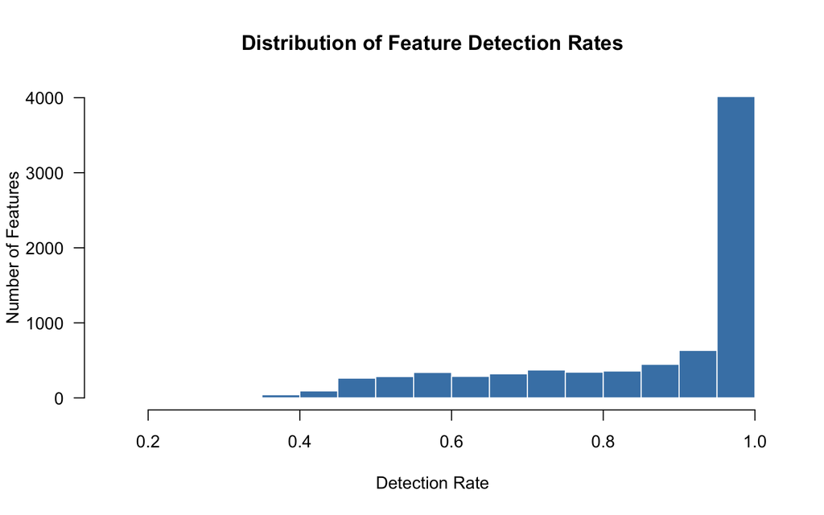

```r
detection_summary <- detection(
  data = feature_data,
  id_col = "sample_id",
  non_detect_values = NA
)

feature_detection_rates <- detection_summary$detection_rates

# distribution of detection rates
hist(
  feature_detection_rates$detection_rate,
  breaks  = 30,
  col     = "steelblue",
  border  = "white",
  main    = "Distribution of Feature Detection Rates",
  xlab    = "Detection Rate",
  ylab    = "Number of Features",
  las     = 1
)
```

The distribution of feature detection rates shows that the majority of features are detected in more than 80% of samples, with a smaller proportion of features detected in fewer samples. As is common in analyzing mass-spec data, we will implement a cutoff of 80%.

Let’s use the same function, `detection`, but supply an argument for `threshold` and `drop`, which removes features whose detection rates are below a specified threshold:

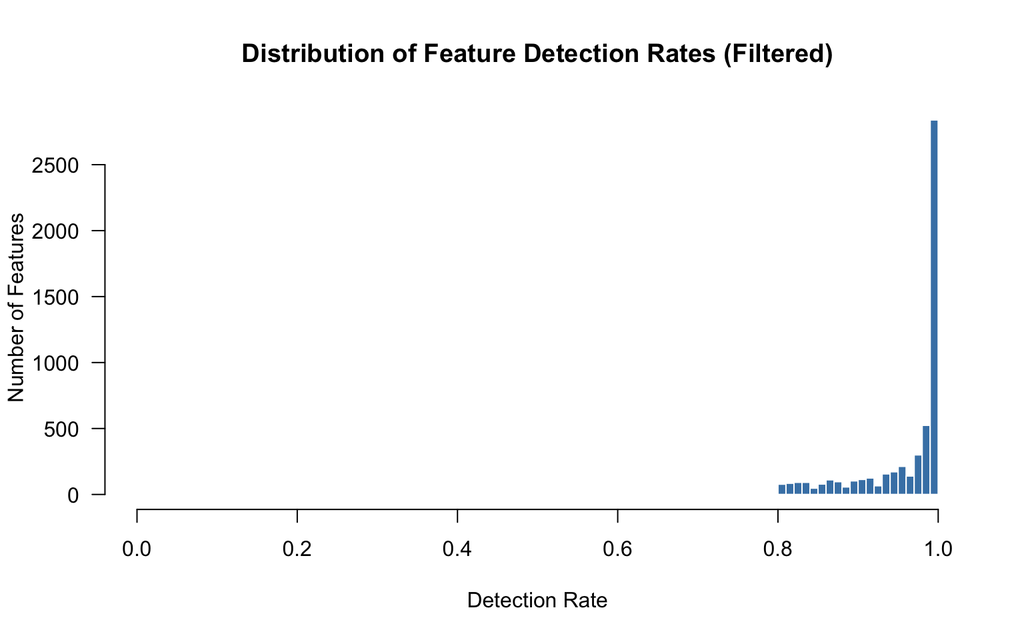

```r
detection_drop <- detection(
  data = feature_data,
  id_col = "sample_id",
  non_detect_values = NA,
  drop = TRUE,
  threshold = 0.8
)

# summary with new filtered data
new_summary <- detection(
  data = detection_drop$data,
  id_col = "sample_id",
  non_detect_values = NA,
  drop = FALSE
)

new_feature_detection_rates <- new_summary$detection_rates

# distribution of detection rates
hist(
  new_feature_detection_rates$detection_rate,
  breaks  = 15,
  col     = "steelblue",
  border  = "white",
  main    = "Distribution of Feature Detection Rates (Filtered)",
  xlab    = "Detection Rate",
  ylab    = "Number of Features",
  las     = 1,
  xlim = c(0, 1)
)
```

```r
# how many features remain after filtering
cat("Features before filtering:", ncol(feature_data) - 1, "\n")
```

```
## Features before filtering: 7830
```

```r
cat("Features after filtering:", ncol(detection_drop$data) - 1, "\n")
```

```
## Features after filtering: 5491
```

```r
cat("Features removed:", (ncol(feature_data) - 1) - (ncol(detection_drop$data) - 1), "\n")
```

```
## Features removed: 2339
```

After applying the 80% detection threshold, 5,491 features were retained for downstream analyses and 2,339 features were removed.

## Replace Values Below the Limit of Detection

There are still features that were not able to be detected within a sample run. These non-detects can be replaced using one of the following methods:

$$\frac{\text{LOD}}{\sqrt{2}}, \quad
\text{LOD}, \quad
0, \quad
\text{user supplied value}$$

This example uses $\text{LOD}/\sqrt{2}$ to replace the non-detects.

```r
feature_data_imputed <- replace_below_lod(
  df = detection_drop$data,
  replacement_method = "lod_sqrt2",
  id_col = "sample_id",
  nondetect_codes = NA
)
```

```
## Starting LOD replacement function
```

```
## ID column detected: sample_id (excluded)
```

```
## Processing 5491 columns...
```

```
## Replacement method: lod_sqrt2
```

```
## Non-detect codes: NA
```

```
## Keep missing: FALSE
```

```
## Replace below LOD: TRUE
```

```
## Replaced 0 values below LOD.
```

```
## Replaced 35511 non-detect values.
```

```
## Replacement complete
```

To verify that this worked, let’s check the total number of `NA` values present in our `feature_data_imputed` dataset. It should be zero now.

```r
sum(is.na(feature_data_imputed))
```

```
## [1] 0
```

Before applying additional normalization, let’s compare the distribution of feature intensities across samples.

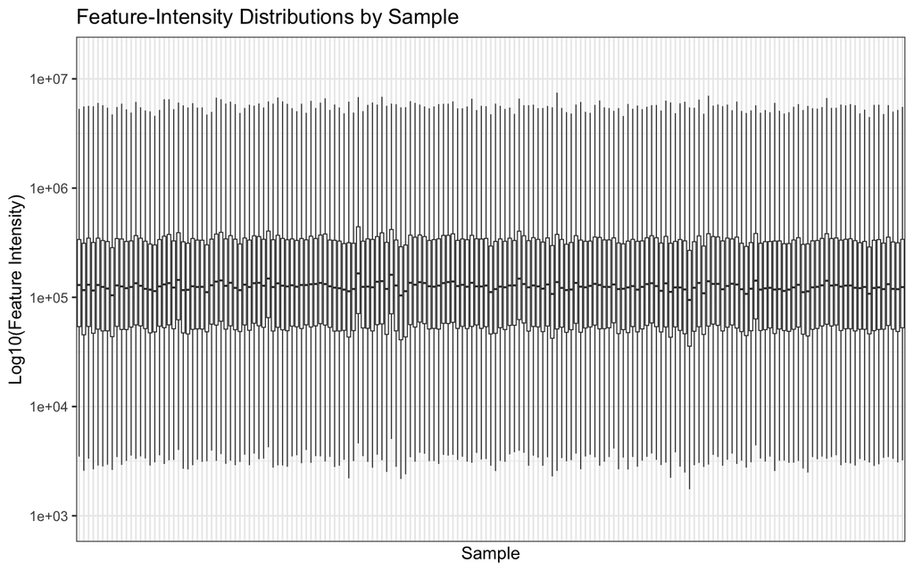

```r
# convert the feature matrix to long format
feature_columns <- setdiff(names(feature_data_imputed),"sample_id")

sample_intensity_data <- data.frame(sample_id = rep(feature_data_imputed$sample_id, each = length(feature_columns)),
                                    intensity = as.vector(t(as.matrix(feature_data_imputed[feature_columns]))))

intensity_limits <- quantile(sample_intensity_data$intensity[sample_intensity_data$intensity > 0], probs = c(0.01, 0.99), na.rm = TRUE)

# plot feature intensities by sample
ggplot(sample_intensity_data, aes(x = sample_id, y = intensity)) +  theme_bw() +
  geom_boxplot(outlier.shape = NA, linewidth = 0.3) +
  scale_y_log10() + coord_cartesian(ylim = intensity_limits) +
  labs(title = "Feature-Intensity Distributions by Sample", x = "Sample", y = "Log10(Feature Intensity)") +
  theme(axis.text.x = element_blank(), axis.ticks.x = element_blank())
```

The distributions appear reasonably similar across samples. Based on this initial review, there is no strong indication that additional sample-level normalization is necessary.

We will proceed to normalize the feature intensities using $log_2$ transformation, but normalization decisions should also consider the laboratory design, quality-control samples, internal standards, batch structure, and expected sources of technical variability.

## Transform the Features

High-dimensional omic feature data often have large variances and are right-skewed due to the presence of a small number of very highly abundant features. A transformation method is commonly applied to reduce skewness, stabilize variance, and linearize relationships before regression modeling. `transform_features()` applies a user-specified transformation to all numeric feature columns. The user can choose from five transformation options: none, natural log, $log_{2}$, $log_{10}$, or boxcox transformation and three scaling options: none, z-score, or pareto scaling.

The $log_2$ transformation method will be applied to this dataset to handle the large variance across features and convert the multiplicative fold changes into intuitive additive differences for easier interpretation of the downstream results. No scaling method will be supplied.

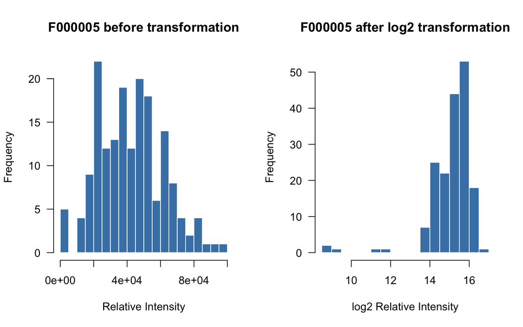

```r
par(mfrow = c(1, 2))
hist(
  as.numeric(feature_data_imputed$F000005),
  breaks = 20,
  col    = "steelblue",
  border = "white",
  main   = "F000005 before transformation",
  xlab   = "Relative Intensity",
  las    = 1
)

transformed_data <- transform_features(
  feature_data_imputed,
  id_col         = "sample_id",
  transform      = "log2",
  scale          = "none"
)

hist(
  as.numeric(transformed_data$F000005),
  breaks = 20,
  col    = "steelblue",
  border = "white",
  main   = "F000005 after log2 transformation",
  xlab   = "log2 Relative Intensity",
  las    = 1
)
```

```r
par(mfrow = c(1, 1))
```

After the $log_2$ transformation is applied to the data, the variance across features is much smaller, reducing heteroskedasticity and helping to better meet the assumptions of parametric statistical testing.

# Exploratory Analysis with `exp_eda()`

## Outlier Detection, PCA, and Covariate Exploration

Now that we have a cleaned dataset containing features above an 80% detection rate and no `NA` values, we can use `exp_eda()` to explore the feature structure through four sequential steps:

```r
eda <- exp_eda(
  transformed_data,
  id_col          = "sample_id",
  rho_thresh      = 0.5,
  min_block_size  = 3,
  batch           = feature_metadata$Batch,
  pheno           = feature_metadata,
  covariates      = c("Age", "BMI", "Sex", "Batch"),
  n_pcs           = 5
)
```

```
## Outlier Detection (> 3 SD from feature mean across samples)
## 175 sample(s) with at least one outlier feature detected.
## Top samples by outlier count:
##   sample n_outliers max_abs_z
## 1  X1145        133  12.10009
## 2  X2138        586  11.99819
## 3  X2130         42  10.83325
## 4  X2067         63  10.61537
## 5  X2131        483  10.49857
## See `sample_severity` in the returned object for all results.
##
## Samples used in PCA (complete cases): 175 out of 175
##
## Variance Explained by Top 5 Principal Components:
##      PC proportion_variance cumulative_variance
## PC1 PC1              0.0617              0.0617
## PC2 PC2              0.0383              0.1000
## PC3 PC3              0.0298              0.1298
## PC4 PC4              0.0241              0.1540
## PC5 PC5              0.0220              0.1759
##
## Top 10 Absolute Loadings for Top 5 PCs:
## Showing first 5 rows. Full table available in returned object.
##    PC feature loading
## 1 PC1 F004903 -0.0463
## 2 PC1 F004881 -0.0458
## 3 PC1 F004514 -0.0452
## 4 PC1 F004500 -0.0451
## 5 PC1 F005246 -0.0451
##
## Batch Effect Assessment (ANOVA):
## No significant batch effect on PC1 (p = 0.966 )
## No significant batch effect on PC2 (p = 0.977 )
```

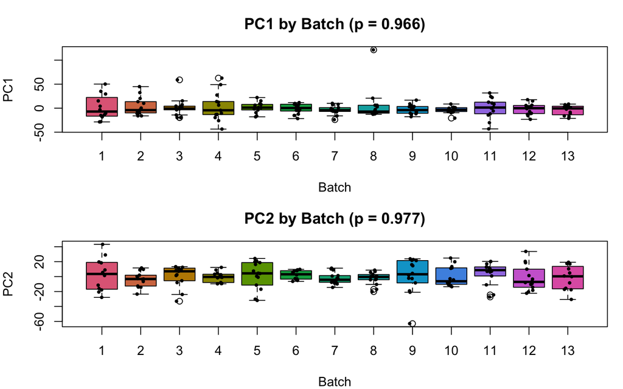

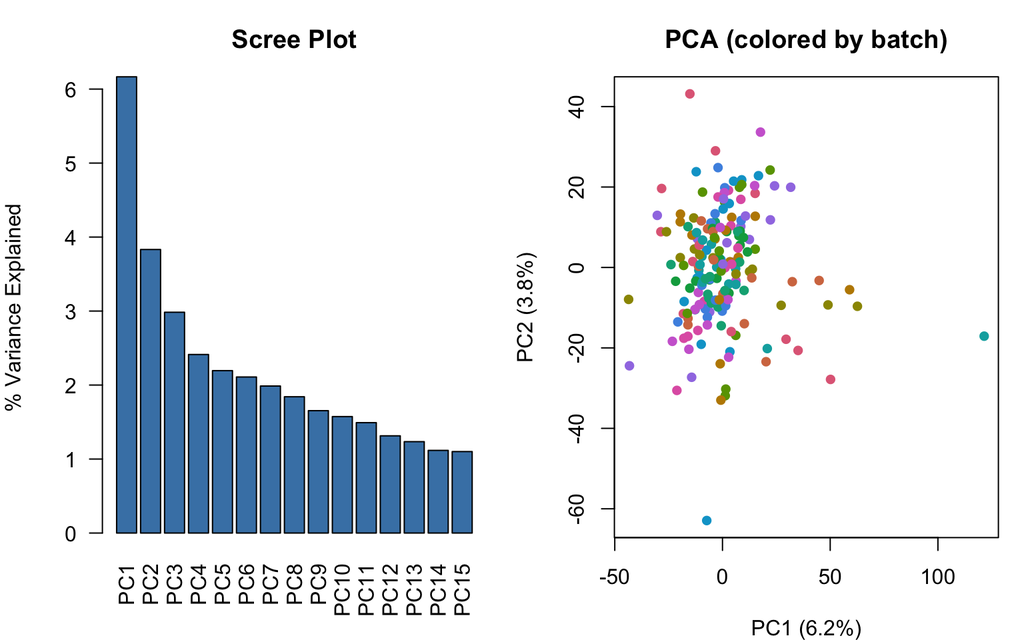

```
##
## Covariate Exploration
## Testing covariate-PC associations against 5 principal component(s) (p < 0.05 ) ...
```

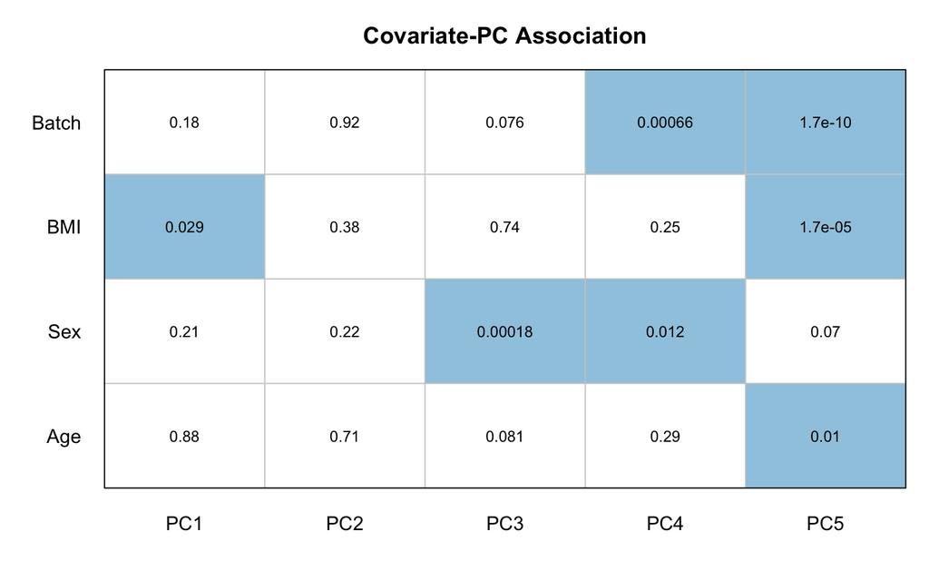

```
## Covariate-PC association heatmap plotted (shaded cells: p < 0.05).
```

```
##
## NOTE: Association with the omic profile does not by itself establish that a variable is a confounder or should be included in an outcome model. Covariate selection should also consider subject-matter knowledge and causal structure.
```

```
##
## Computing correlation matrix...
##   |                                                                              |                                                                      |   0%  |                                                                              |=                                                        …
##
## Correlation Blocks (rho >= 0.5 , min size 3 ):
## Showing first 5 of 221 blocks. Full table available in returned object.
##   block n_features
## 1   698         47
## 2   576         44
## 3  1215         28
## 4  2714         25
## 5  1898         24
```

1. **Outlier detection** - The outlier detection step flags all 175 samples as having at least one feature value exceeding 3 standard deviations from that feature’s mean across the cohort. This is expected in high-dimensional untargeted metabolomics data: with 5,491 features, the probability that any given sample has at least one extreme value by chance alone is very high. The more informative metric is the outlier count per sample.

   The covariate-PC association heatmap reveals that all covariates supplied are significantly associated with at least one of the top five principal components. Batch had significant associations with PC4 and PC5, indicating that batch is a driver of variation. Batch effects of this magnitude are common in untargeted metabolomics studies where samples are analyzed across multiple instrument runs. This finding supports the inclusion of batch as a random intercept in the mixed-effects model using `run_mixed()`.BMI also shows significant associations with PC1 and PC5, suggesting that body mass index is meaningfully related to the overall metabolic profile. This is consistent with the well-established influence of adiposity on circulating metabolite concentrations. Sex is associated with PC3 and PC4, supporting sex-specific differences in the metabolome that should be adjusted for in downstream models. Age shows an association with PC5, suggesting a relationship between age and metabolomic variation. All four covariates should be retained in downstream regression models given both their significant PC associations and biological relevance to metabolite profiles.
4. **Correlation block detection** - The correlation block detection identified 221 blocks of highly correlated features (Spearman $rho >= 0.5$, minimum block size of 3). The largest block contains 47 features, followed by blocks of 44, 28, 25, and 24 features. Features within the same block likely represent either the same metabolite measured as multiple ion forms, for example adducts, isotopes, or in-source fragments, or metabolites from the same biochemical pathway that co-vary across participants. The blocks created in this step can be passed directly in the `run_category()` function to test associations between metabolite categories and outcomes.

   The full block membership table is available in the returned object:

```r
eda$correlation_summary
```

# Metabolome-Wide Regression with `run_regression()`

`run_regression()` is the core `ExpoMet` function. It iterates over each feature and fits a separate generalized linear model with that feature substituted in place of the `omic_features` placeholder in the formula. After all models are fitted, FDR correction is applied across all feature p-values using the Benjamini-Hochberg method.

The model fitted for each feature $j$ is:

$$g(\nu_{ij}) = \beta_{0j} + \beta_j \cdot \text{TCE}_i + \gamma_{1j}
\cdot \text{Age}_i +
\gamma_{2j} \cdot \text{BMI}_i + \gamma_{3j} \cdot
\text{Sex}_i$$

where $\beta_j$ is the coefficient of interest and the covariates are estimated separately for each feature. $\text{Age}_i$ and $\text{BMI}_i$ are continuous, while $\text{Sex}_i$ is a binary covariate, encoding female as 0 and male as 1.

## Continuous outcome

In this example, `omic_features` appears on the left-hand side of the formula, meaning each omic feature is the outcome and TCE exposure concentration is the predictor. This investigates associations between TCE exposure and each molecular feature while adjusting for age, sex, and body mass index.

```r
results_cont <- run_regression(
  omic_features ~ TCE_Exp_Conc + Age + BMI + factor(Sex),
  feature_metadata,
  transformed_data,
  id_col       = "sample_id",
  progress_bar = FALSE,
)
```

```
## 175 participants matched across pheno and omic_features data frames
```

```
## 5491 feature variables identified in omic_features
```

```
## Bonferroni threshold based on 5491 test(s) in stratum 'all' (threshold = 9.11e-06).
```

```
## 2 feature(s) survived Bonferroni correction in stratum 'all'.
```

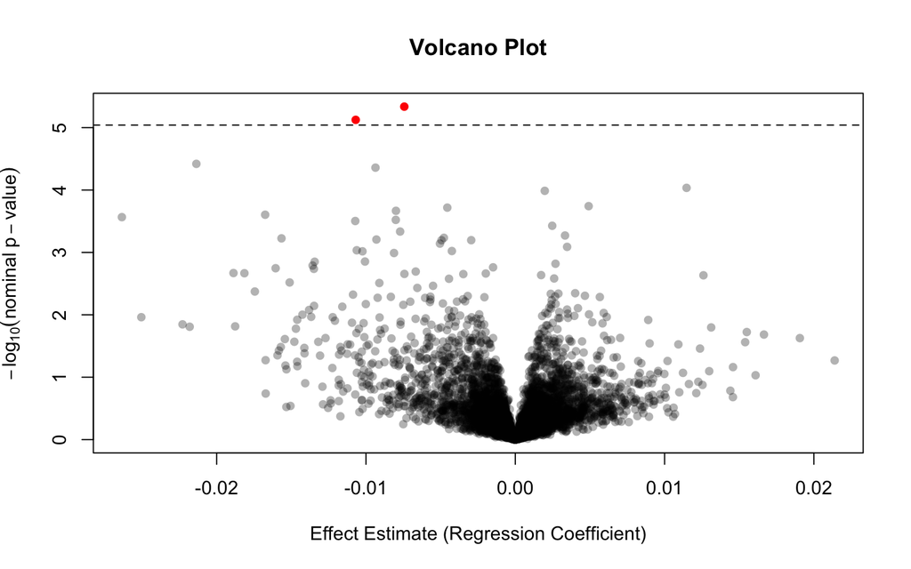

```r
head(results_cont$results, 5)
```

```
##   variable         term     estimate   std_error          lcl          ucl
## 1  F006283 TCE_Exp_Conc -0.007434291 0.001570251 -0.010511984 -0.004356599
## 2  F002780 TCE_Exp_Conc -0.010688221 0.002312711 -0.015221135 -0.006155307
## 3  F000676 TCE_Exp_Conc -0.021360312 0.005049280 -0.031256900 -0.011463724
## 4  F006025 TCE_Exp_Conc -0.009364033 0.002231937 -0.013738629 -0.004989437
## 5  F001210 TCE_Exp_Conc  0.011471140 0.002863821  0.005858052  0.017084229
##        p_value        fdr significant
## 1 4.606218e-06 0.02059520        TRUE
## 2 7.501438e-06 0.02059520        TRUE
## 3 3.805944e-05 0.06008956       FALSE
## 4 4.377313e-05 0.06008956       FALSE
## 5 9.234871e-05 0.09422521       FALSE
```

The resulting table contains one row per feature and includes the estimated coefficient, standard error, lower and upper 95% confidence limits, nominal p-value, FDR-adjusted p-value (default: FDR < $0.05$), and a significance indicator.

In this example, the two features with the smallest p-values (F006283 and F002780) survived FDR correction. Both coefficient estimates are negative, indicating that higher TCE exposure concentration is associated with lower relative abundance of these features. Because the feature intensities were $log_2$ transformed, each coefficient represents the change in $log_2$ intensity per 1 ppm increase in TCE exposure and can be expressed as a fold change via $2^{\beta}$. For F006283 ($β = −0.0074$), each 1 ppm increase in TCE exposure corresponds to an approximately 0.5% lower relative intensity. For F002780 ($β = −0.0107$), the corresponding decrease is approximately 0.7% per 1 ppm.

## Feature-wide association results

For mass-spectrometry data, molecular features can be displayed according to their retention time rather than a genomic position. Features with similar retention times that cluster together above the significance threshold may reflect chemically related compounds, which can help guide downstream annotation and interpretation.

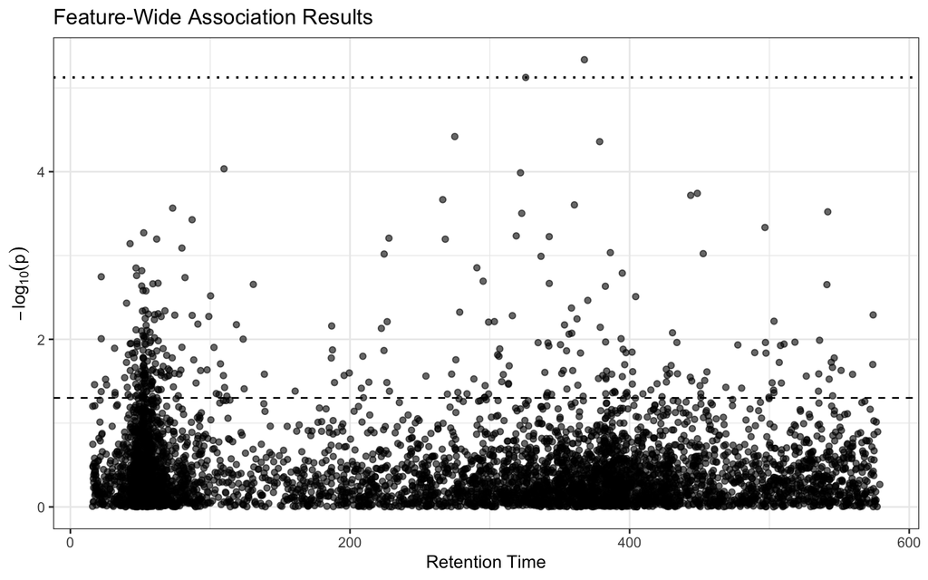

```r
# merge regression results with feature key annotation
association_plot_data        <- results_cont$results
# change to numeric
association_plot_data$p_value <- as.numeric(association_plot_data$p_value)
association_plot_data$fdr     <- as.numeric(association_plot_data$fdr)

# merge feature key annotation
association_plot_data$mz   <- feature_key$mz[
  match(association_plot_data$variable, feature_key$feature_id)]
association_plot_data$time <- as.numeric(feature_key$time[
  match(association_plot_data$variable, feature_key$feature_id)])

association_plot_data$negative_log10_p <- -log10(association_plot_data$p_value)

# significance thresholds
nominal_threshold <- -log10(0.05)

fdr_significant_pvalues <- association_plot_data$p_value[
  !is.na(association_plot_data$fdr) & association_plot_data$fdr < 0.05]

fdr_threshold <- if (length(fdr_significant_pvalues) > 0) {
  -log10(max(fdr_significant_pvalues))
} else {
  NA_real_
}

ggplot(association_plot_data, aes(x = time, y = negative_log10_p)) +
  theme_bw() +
  geom_point(alpha = 0.6, size = 1.5) +
  geom_hline(yintercept = nominal_threshold,
             linetype   = "dashed",
             linewidth  = 0.5) +
  geom_hline(yintercept = fdr_threshold,
             linetype   = "dotted",
             linewidth  = 0.7) +
  labs(
    title = "Feature-Wide Association Results",
    x     = "Retention Time",
    y     = expression(-log[10](p))
  )
```

The dashed line represents the nominal p-value threshold of 0.05. The dotted line represents the raw p-value corresponding to an FDR threshold of 0.05, based on the largest raw p-value among all FDR-significant results.

Nominal statistical significance should not be interpreted as evidence that a result is unlikely to be a false positive when thousands of features have been tested. Multiple-testing correction is necessary even when individual p-values appear very small. Features above the dotted FDR line represent the most statistically reliable associations after accounting for the scale of testing.

```r
# extract significant hits with annotation
sig_annotated <- association_plot_data[
  !is.na(association_plot_data$fdr) &
  association_plot_data$fdr < 0.05, ]

sig_annotated <- sig_annotated[order(sig_annotated$p_value),
                               c("variable", "mz", "time",
                                 "estimate", "p_value", "fdr")]

head(sig_annotated, 10)
```

```
##   variable       mz     time     estimate      p_value       fdr
## 1  F006283 450.2012 367.6582 -0.007434291 4.606218e-06 0.0205952
## 2  F002780 251.1279 325.6814 -0.010688221 7.501438e-06 0.0205952
```

The `mz` and `time` columns can be used to query spectral databases such as MassBank, mzCloud, or METLIN for putative compound annotation, or submitted directly to `format_mummichog_input()` for pathway analysis.

# Mummichog Pathway Analysis

Mummichog is designed specifically for untargeted metabolomics data, using mass-to-charge ratios and retention times to infer pathway enrichment without prior compound annotation. Pathway analysis tools for other omic data types, such as GSEA and ORA for transcriptomics, or ChemRICH for annotated chemical exposomics data, are not included in ExpoMet as they are better handled by dedicated packages such as `clusterProfiler` and `fgsea`. `format_mummichog_input()` formats results for direct submission to MetaboAnalyst, which provides a web-based implementation of Mummichog and related pathway methods.

```r
format_mummichog_input(
  exposure = "TCE_Exp_Conc",
  input_df1 = results_cont$results,
  annotation_df_list = feature_key,
  feature_col = "feature_id",
  mz_col = "mz",
  rt_col = "time",
  p_col = "p_value",
  output_dir = tempdir()
)
```

Here the file is written to a temporary directory. In your own analysis, set output_dir to a folder you can easily find, since this is the file you will upload to MetaboAnalyst.

## Complete the Pathway Analysis in MetaboAnalyst

After exporting the formatted input file:

1. Open the MetaboAnalyst website and select **Start**
2. Choose **Functional Analysis [LC-MS]**
3. Upload the file created by `format_mummichog_input()`
4. Select **Positive Mode** (it’s true in this case, but may not be true in every case)
5. Keep the mass tolerance of **5.0 ppm** (default)
6. Indicate that retention time is measured in **seconds**
7. Indicate that features were ranked by their **p-values**
8. Continue through the remaining analysis steps and examine the pathway results

Pathway-analysis results require cautious interpretation. A statistically enriched pathway does not establish that the pathway itself caused the observed association. Results can be influenced by feature annotation, correlated peaks, adducts, isotopes, pathway size, database coverage, and the selection of analysis parameters.

# Stratified MWAS Regression Analysis

The `stratify` argument runs separate models for each level of a grouping variable. This is useful when the relationship between features and the outcome may differ by a participant characteristic. The stratification variable should be removed from the formula to avoid collinearity within strata.

Given that TCE exposure can differ in its metabolic effects by sex and that sex was identified as a significant predictor of the metabolome’s principal components in `exp_eda()`, we stratify by sex to test whether the metabolomic response to TCE differs between male and female workers.

```r
results_strat <- run_regression(
  omic_features ~ TCE_Exp_Conc + Age + BMI,
  feature_metadata,
  transformed_data,
  id_col   = "sample_id",
  stratify = "Sex",
  progress_bar = FALSE
)
```

```
## 175 participants matched across pheno and omic_features data frames
```

```
## 5491 feature variables identified in omic_features
```

```
## Stratifying by 'Sex': 2 strata detected (Female, Male)
```

```
##
## Stratum: Sex = Female (n = 46)
```

```
## Bonferroni threshold based on 5491 test(s) in stratum 'Female' (threshold = 9.11e-06).
```

```
## No features survived Bonferroni correction in stratum 'Female'.
```

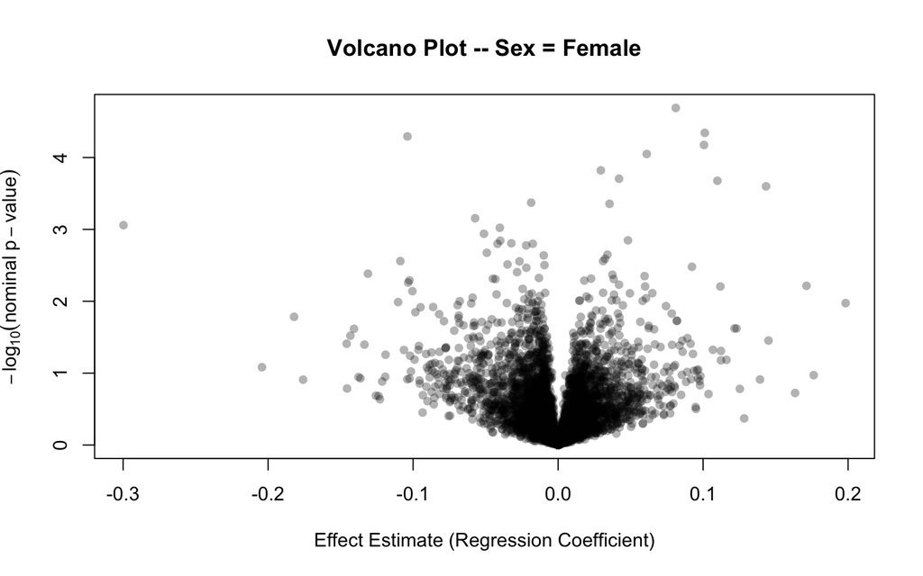

```
##
## Stratum: Sex = Male (n = 129)
```

```
## Bonferroni threshold based on 5491 test(s) in stratum 'Male' (threshold = 9.11e-06).
```

```
## No features survived Bonferroni correction in stratum 'Male'.
```

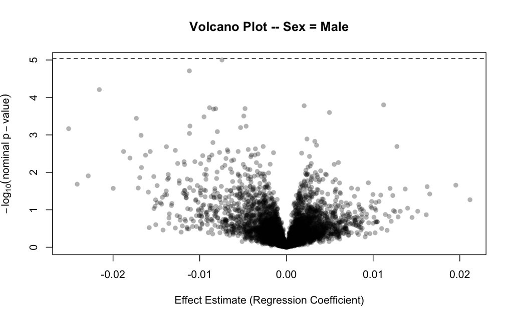

```r
head(results_strat[["Female"]]$results, 5)
```

```
##   variable         term    estimate  std_error         lcl         ucl
## 1  F003205 TCE_Exp_Conc  0.08113785 0.01690900  0.04799621  0.11427948
## 2  F003524 TCE_Exp_Conc  0.10117975 0.02224175  0.05758593  0.14477358
## 3  F004047 TCE_Exp_Conc -0.10389254 0.02302066 -0.14901304 -0.05877205
## 4  F003557 TCE_Exp_Conc  0.10060739 0.02272744  0.05606160  0.14515318
## 5  F005875 TCE_Exp_Conc  0.06112459 0.01410200  0.03348468  0.08876451
##        p_value        fdr significant    Sex
## 1 2.042348e-05 0.09174484       FALSE Female
## 2 4.536035e-05 0.09174484       FALSE Female
## 3 5.086492e-05 0.09174484       FALSE Female
## 4 6.683289e-05 0.09174484       FALSE Female
## 5 8.932093e-05 0.09809224       FALSE Female
```

```r
head(results_strat[["Male"]]$results, 5)
```

```
##   variable         term     estimate    std_error          lcl          ucl
## 1  F006283 TCE_Exp_Conc -0.007436048 0.0016145582 -0.010600582 -0.004271514
## 2  F002780 TCE_Exp_Conc -0.011197085 0.0025213899 -0.016139009 -0.006255160
## 3  F000676 TCE_Exp_Conc -0.021581302 0.0052045624 -0.031782244 -0.011380360
## 4  F001210 TCE_Exp_Conc  0.011210695 0.0028765080  0.005572739  0.016848650
## 5  F000019 TCE_Exp_Conc  0.002047126 0.0005273071  0.001013604  0.003080647
##        p_value        fdr significant  Sex
## 1 9.978130e-06 0.05347914       FALSE Male
## 2 1.947883e-05 0.05347914       FALSE Male
## 3 6.180416e-05 0.11312221       FALSE Male
## 4 1.576812e-04 0.12469097       FALSE Male
## 5 1.666747e-04 0.12469097       FALSE Male
```

When stratification is used, the function returns a named list with one entry per stratum. Each entry contains its own `$results` table and `$plot`.

The stratified results differ between female and male participants. No feature survives FDR correction in either stratum at the default threshold of 0.05; the closest are the top two features in males (F006283 and F002780, FDR = 0.053), which are also the two significant features in the full-sample model, with nearly identical estimates. The top-ranked features in females (F003205, F003524, F004047, F003557, F005875; FDR = 0.09–0.10) do not overlap with those in males and have estimates roughly ten times larger. With only 46 female participants compared with 129 males, the female estimates are less precise, and the full-sample results are largely driven by the male stratum.

# Mixed-Effects MWAS with `run_mixed()`

When samples are clustered by batch, site, or another grouping variable, ignoring this structure can produce incorrect standard errors and p-values. `run_mixed()` addresses this by fitting linear or generalized linear mixed-effects models using `lme4`. The random effects structure is specified directly in the formula.

The model fitted for each feature $j$ with a random intercept for batch is:

$$g(\nu_{ij}) = \beta_{0j} + \beta_j y_i + \boldsymbol{\gamma}^T_j
\mathbf{c}_i + b_{j,k[i]}, \quad b_{jk} \sim \mathcal{N}(0,
\sigma^2_{b,j})$$

where $\beta_{0j}$ is the average baseline level of feature $j$ across all batches, $\beta_j$ is the coefficient of interest for exposure $y_i$, $\boldsymbol{\gamma}_j$ are the coefficients for the covariates $\mathbf{c}_i$, and $b_{j,k[i]}$ is the random intercept for the batch $k$ containing participant $i$. Each batch’s baseline for feature $j$ is $\beta_{0j} + b_{jk}$. The random intercepts are assumed to follow a normal distribution centered at zero with batch-level variance $\sigma^2_{b,j}$, so batches are allowed to shift above or below the average baseline, and the estimate of $\beta_j$ accounts for this clustering.

Because `lme4` does not provide p-values for fixed effects under Gaussian models, `run_mixed()` computes p-values using the Wald z-test (normal approximation): $p = 2\Phi(-|z|)$ where $z = \hat{\beta}_j / \text{SE}(\hat{\beta}_j)$.

When samples are processed across multiple mass-spectrometry batches, systematic technical differences between batches can introduce variation that is unrelated to the biological exposure of interest. Failing to account for this clustering structure can produce inaccurate standard errors and p-values. The covariate-PC association analysis identified that batch is significantly associated with two of the top five PC’s, suggesting that batch effects may be apparent in this dataset. `run_mixed()` addresses this by including batch as a random intercept, allowing each batch to have its own baseline feature abundance while sharing information across batches to estimate the TCE-feature association.

```r
results_mixed <- run_mixed(
  omic_features ~ TCE_Exp_Conc + Age + BMI + factor(Sex) + (1 | Batch),
  feature_metadata,
  transformed_data,
  id_col       = "sample_id",
  progress_bar = FALSE
)
```

```
## 175 participants matched across pheno and omic_features data frames
```

```
## 5491 feature variables identified in omic_features
```

```
##
## 3403 of 5491 feature(s) produced singular fits in stratum 'all' -- a random-effect variance was estimated as zero. Results are included but should be interpreted with caution.
```

```
## Bonferroni threshold based on 5491 test(s) in stratum 'all' (threshold = 9.11e-06).
```

```
## 2 feature(s) survived Bonferroni correction in stratum 'all'.
```

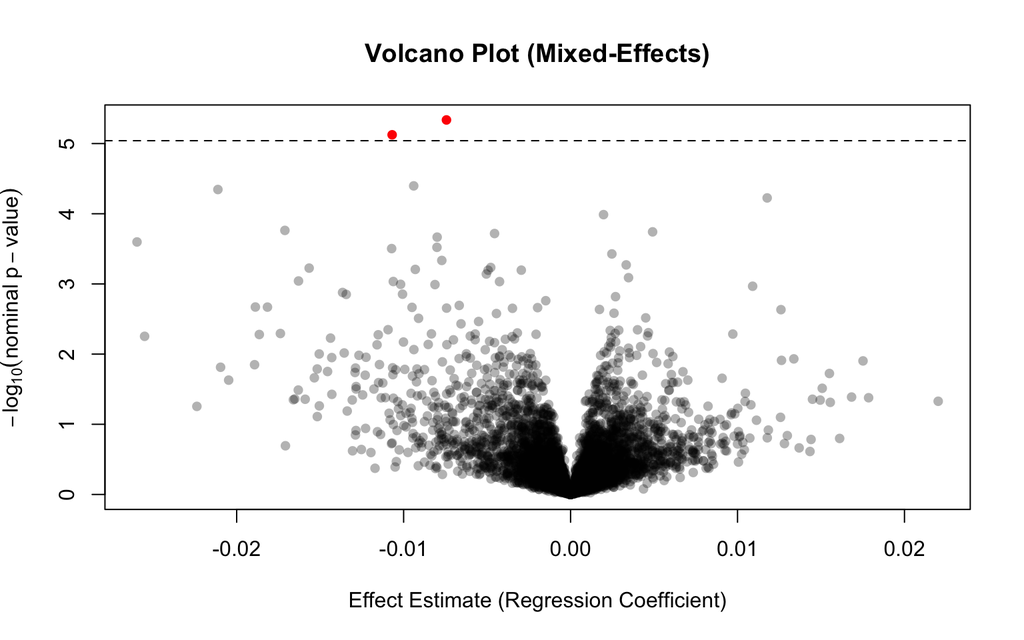

```r
head(results_mixed$results, 5)
```

```
##   variable         term     estimate   std_error         lcl          ucl
## 1  F006283 TCE_Exp_Conc -0.007434291 0.001570251 -0.01051198 -0.004356599
## 2  F002780 TCE_Exp_Conc -0.010688221 0.002312711 -0.01522113 -0.006155307
## 3  F006025 TCE_Exp_Conc -0.009396358 0.002227940 -0.01376312 -0.005029597
## 4  F000676 TCE_Exp_Conc -0.021124341 0.005044446 -0.03101145 -0.011237228
## 5  F001210 TCE_Exp_Conc  0.011775242 0.002859338  0.00617094  0.017379544
##        p_value        fdr significant
## 1 4.606218e-06 0.02059520        TRUE
## 2 7.501438e-06 0.02059520        TRUE
## 3 4.007634e-05 0.06199836       FALSE
## 4 4.516362e-05 0.06199836       FALSE
## 5 5.949501e-05 0.06533742       FALSE
```

After adjusting for batch, the same two features identified by `run_regression()` (F006283 and F002780) remain the only associations surviving FDR correction (FDR = $0.021$), with identical effect estimates. For 3,403 of the 5,491 features, the batch random-intercept variance was estimated as zero (a singular fit), meaning batch explained no additional variation in those features beyond the fixed-effect covariates. Although batch dominates the principal axes of variation across the metabolome, accounting for it did not alter the TCE–feature associations in this dataset.

# Category-Level Regression with `run_category()`

The 221 correlation categories/blocks identified by `exp_eda()` group features that co-vary strongly across participants and likely reflect shared metabolic origins, for example, the same metabolite measured as multiple ion forms (adducts, isotopes, in-source fragments). Rather than testing each of the 5,491 features individually, `run_category()` summarizes each block into a single representative score and tests the block-level association with TCE exposure. This reduces the multiple testing burden from 5,491 individual feature tests to 221 block-level tests while preserving biologically meaningful groupings.

Two summary methods are available. The `"pc1"` method extracts the first principal component of each block, capturing the main source of co-variation among the block’s features. The `"zscore"` method standardizes each feature within the block and averages the standardized values, producing a composite score representing the overall activity level of the block.

The correlation blocks from `exp_eda()` are passed directly to the `categories` argument:

```r
results_cat <- run_category(
  omic_features ~ TCE_Exp_Conc + Age + BMI + factor(Sex),
  feature_metadata,
  transformed_data,
  id_col         = "sample_id",
  categories     = eda$correlation_blocks,
  summary_method = "pc1",
  progress_bar   = FALSE
)
```

```
## Running category-level regression on 221 categories using pc1 summary method.
##
## Computing category summary scores...
```

```
## 175 participants matched across pheno and omic_features
```

```r
head(results_cat$results, 5)
```

```
##   category         term n_features summary_method    estimate   std_error
## 1     1096 TCE_Exp_Conc          6            pc1 -0.02154550 0.005860136
## 2      181 TCE_Exp_Conc          3            pc1  0.01401235 0.004026738
## 3     2154 TCE_Exp_Conc          5            pc1  0.01843330 0.005430601
## 4      624 TCE_Exp_Conc          3            pc1 -0.01264805 0.003847196
## 5     1469 TCE_Exp_Conc          4            pc1 -0.01483321 0.004561933
##            lcl          ucl      p_value        fdr significant
## 1 -0.033031363 -0.010059629 0.0003166826 0.06118346       FALSE
## 2  0.006119946  0.021904757 0.0006374808 0.06118346       FALSE
## 3  0.007789324  0.029077278 0.0008561662 0.06118346       FALSE
## 4 -0.020188550 -0.005107541 0.0012278114 0.06118346       FALSE
## 5 -0.023774597 -0.005891819 0.0013842412 0.06118346       FALSE
```

Each row in the results table corresponds to one correlation block, with the estimated regression coefficient for the block’s PC1 score, its standard error, 95% confidence limits, nominal p-value, and FDR-adjusted p-value. A significant block-level association indicates that the overall metabolic activity of that cluster is associated with TCE exposure.

To identify which specific metabolites belong to these blocks, examine the block membership directly:

```r
# features in the top-ranked blocks
eda$correlation_blocks[["1096"]]
```

```
## [1] "F001436" "F002064" "F002079" "F002780" "F002799" "F004963"
```

```r
eda$correlation_blocks[["181"]]
```

```
## [1] "F000201" "F000465" "F001210"
```

These features can then be cross-referenced with the individual MWAS results from `run_regression()` to determine whether the same features show associations at the individual level.

# Model Diagnostics with `model_diagnostics()`

After fitting these models, it is important to assess whether the distribution of test statistics is consistent with what would be expected under the null hypothesis. `model_diagnostics()` provides two tools for this purpose: the genomic inflation factor ($\lambda$) and the quantile-quantile (QQ) plot.

The genomic inflation factor is calculated as:

$$\lambda = \frac{\text{median}(\chi^2_{\text{observed}})}
{\text{median}(\chi^2_{\text{null}})}$$

where $\chi^2_{\text{observed}}$ are the association test statistics across all $p$ features, expressed as 1-degree-of-freedom chi-square statistics, and $\text{median}(\chi^2_{\text{null}}) \approx 0.455$ is the median of a $\chi^2_1$ distribution, the value expected if no features were associated with the outcome. A value of $\lambda$ close to 1 indicates that the observed distribution is broadly consistent with the null. Values substantially greater than 1 may indicate residual confounding or model misspecification.

The Q-Q plot compares the observed $-\log_{10}$ p-values against those expected under the null hypothesis of no association. Points close to the diagonal indicate that the p-values are behaving as expected under the null hypothesis. Deviation confined to the upper tail suggests true associations among a small number of features, while early and systematic deviation above the line suggests inflation due to confounding or other sources of bias.

When two models are supplied, `model_diagnostics()` additionally compares their regression coefficients and p-values. Coefficient comparison uses Spearman correlation of the coefficient estimates. P-values are compared on the $-\log_{10}$ scale.

```r
diag_mixed <- model_diagnostics(
  model1       = results_cont$results,
  model2       = results_mixed$results,
  model1_name  = "Linear regression",
  model2_name  = "Mixed effects (1 | Batch)",
  feature_col  = "variable",
  estimate_col = "estimate",
  se_col       = "std_error",
  p_col        = "p_value",
  fdr_col      = "fdr"
)
```

```
##
## Model diagnostics: Linear regression
```

```
## Number of features: 5491
```

```
## Lambda: 0.964
```

```
## Features with p < 0.05: 331
```

```
##
## Model comparison: Linear regression vs Mixed effects (1 | Batch)
```

```
## Number of features compared: 5491
```

```
## Coefficient correlation: 0.979
```

```
## P-value correlation: 0.966
```

```
## Linear regression lambda: 0.964
```

```
## Mixed effects (1 | Batch) lambda: 0.977
```

```r
diag_mixed$lambda
```

```
##         Linear regression Mixed effects (1 | Batch)
##                 0.9643280                 0.9766728
```

```r
diag_mixed$correlations$coefficient
```

```
## [1] 0.9793811
```

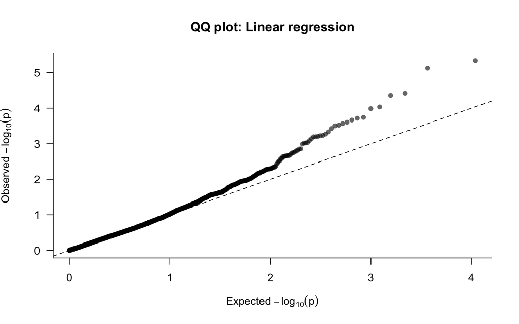

```r
diag_mixed$qq_plot_model1
```

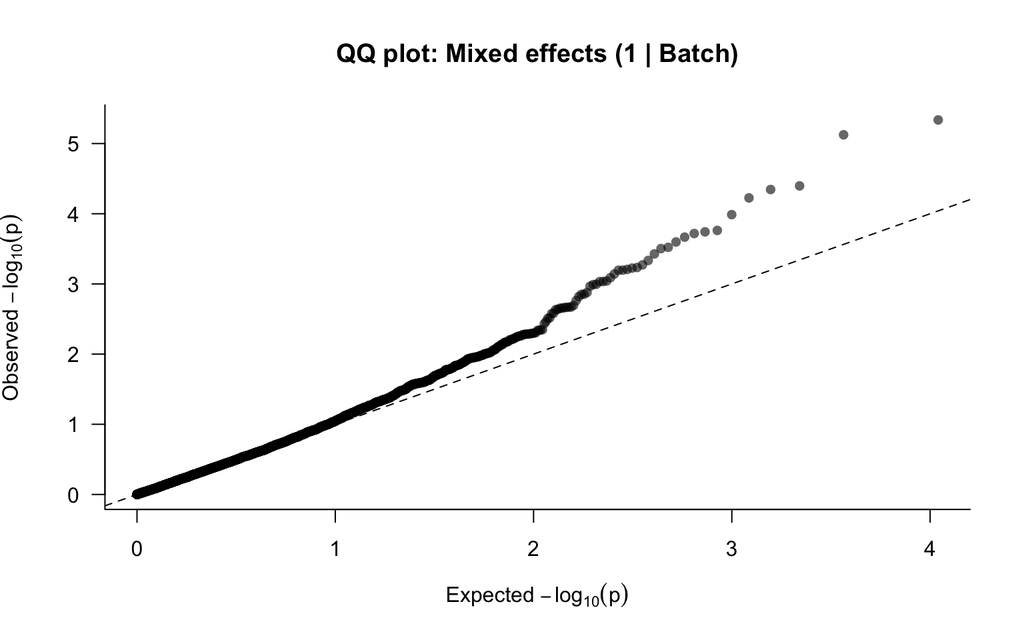

```r
diag_mixed$qq_plot_model2
```

The genomic inflation factors for the linear regression ($λ = 0.96$) and mixed-effects model ($λ = 0.98$) are both close to 1, indicating that the distributions of test statistics are consistent with the null hypothesis and that accounting for batch did not drastically change the model’s calibration.

`model_diagnostics` can be used to compare two models. To compare the sex-stratified results, we pass the stratum-specific results as two models. This assesses whether associations replicate across strata and whether effect sizes are consistent between groups.

```r
diag2 <- model_diagnostics(
  model1       = results_strat[["Female"]]$results,
  model2       = results_strat[["Male"]]$results,
  model1_name  = "Female",
  model2_name  = "Male",
  feature_col  = "variable",
  estimate_col = "estimate",
  se_col       = "std_error",
  p_col        = "p_value",
  fdr_col      = "fdr",
  compare      = "both"
)
```

```
##
## Model diagnostics: Female
```

```
## Number of features: 5491
```

```
## Lambda: 1.100
```

```
## Features with p < 0.05: 310
```

```
##
## Model comparison: Female vs Male
```

```
## Number of features compared: 5491
```

```
## Coefficient correlation: 0.025
```

```
## P-value correlation: 0.031
```

```
## Female lambda: 1.100
```

```
## Male lambda: 0.918
```

```r
diag2$lambda
```

```
##    Female      Male
## 1.0999824 0.9177697
```

```r
diag2$correlations$coefficient
```

```
## [1] 0.02524655
```

```r
diag2$n_features_compared
```

```
## [1] 5491
```

The genomic inflation factor for the female stratum ($λ = 1.10$) is modestly elevated, while the male stratum ($λ = 0.92$) is slightly below 1, indicating mildly conservative test statistics. The correlation of coefficient estimates between strata is near zero ($r = 0.03$), indicating that the associations observed in female participants are largely different from those in male participants. However, this should be interpreted cautiously: with only 46 female participants compared with 129 males, female estimates are considerably less precise, and low between-strata correlation is expected when one stratum’s estimates are dominated by sampling noise. The stratified comparison is therefore better viewed as hypothesis-generating than as evidence of sex-specific responses to TCE exposure.

# Other Useful Functions in `ExpoMet`

## Survival Analysis with `run_cox()`

For time-to-event outcomes, `run_cox()` fits a Cox proportional hazards model for each feature. The `Surv()` outcome is specified directly in the formula using standard `survival` package notation. The model fitted for each feature $j$ is:

$$h_{ij}(t) = h_{0j}(t) \exp\left(\beta_j x_{ij} +
\boldsymbol{\gamma}^T_j \mathbf{c}_i\right)$$

where $h_{0j}(t)$ is an unspecified baseline hazard function, $\beta_j$ is the log hazard ratio for feature $j$, $\mathbf{c}_i$ is a vector of covariates, and $h_{ij}(t)$ is the hazard for participant $i$ at time $t$. The results table includes the estimated log hazard ratio (`estimate`), the exponentiated hazard ratio (`hazard_ratio`), standard error, confidence limits, and p-value for each feature.

```r
data(transform_example)
data(cox_pheno_example)

results_cox <- run_cox(
  Surv(time_to_event, event) ~ omic_features + Age + BMI,
  cox_pheno_example,
  transform_example,
  id_col       = "sample_id",
  progress_bar = FALSE,
  plot         = FALSE
)
```

```
## 50 participants matched across pheno and omic_features data frames
```

```
## 11 feature variables identified in omic_features
```

```
## Bonferroni threshold based on 11 test(s) in stratum 'all' (threshold = 0.00455).
```

```
## No features survived Bonferroni correction in stratum 'all'.
```

```r
head(results_cox$results, 5)
```

```
##   variable term      estimate hazard_ratio    std_error           lcl
## 1     F006 F006  0.0005249793    1.0005251 0.0002162527  0.0001011241
## 2     F003 F003 -0.0011174023    0.9988832 0.0007326663 -0.0025534282
## 3     F009 F009 -0.0005408454    0.9994593 0.0004009929 -0.0013267914
## 4     F007 F007 -0.0006437988    0.9993564 0.0006880252 -0.0019923283
## 5     F004 F004  0.0003552226    1.0003553 0.0005089188 -0.0006422583
##            ucl    p_value       fdr significant
## 1 0.0009488346 0.01519825 0.1671808       FALSE
## 2 0.0003186236 0.12722973 0.6505115       FALSE
## 3 0.0002451006 0.17741223 0.6505115       FALSE
## 4 0.0007047307 0.34941750 0.9608981       FALSE
## 5 0.0013527035 0.48518054 0.9670428       FALSE
```

Because feature intensities are $\log_2$-transformed, each hazard ratio represents the change in the hazard of the event for each doubling of a feature’s intensity. A hazard ratio of 1 indicates no association, a hazard ratio above 1 indicates a higher event rate with higher feature levels, and a hazard ratio below 1 indicates a lower event rate. For example, a hazard ratio of 1.25 means that each doubling of the feature’s intensity is associated with a 25% higher hazard of the event. When samples are clustered, `cluster()` can be added to the formula to obtain robust standard errors:

```r
results_cox_cluster <- run_cox(
  Surv(time_to_event, event) ~ omic_features + Age + BMI + cluster(Sex),
  cox_pheno_example,
  transform_example,
  id_col       = "sample_id",
  progress_bar = FALSE,
  plot         = FALSE
)
```

```
## 50 participants matched across pheno and omic_features data frames
```

```
## 11 feature variables identified in omic_features
```

```
## Bonferroni threshold based on 11 test(s) in stratum 'all' (threshold = 0.00455).
```

```
## 3 feature(s) survived Bonferroni correction in stratum 'all'.
```

## Meta-Analysis with `meta_analysis()`

When ExWAS or MWAS results are available from multiple independent cohorts, `meta_analysis()` performs fixed-effect inverse-variance weighted meta-analysis. This is equivalent to the `rma()` function from the [`metafor`](https://www.metafor-project.org) package with `method = "FE"`, and users familiar with `metafor` will recognize the underlying methodology. `metafor` provides a comprehensive suite of meta-analytic methods, including random-effects models, mixed-effects models, and a wide range of diagnostic plots such as forest, funnel, and radial plots, and is recommended when more advanced meta-analytic options are needed. `meta_analysis()` is designed as a convenience function for the specific use case of fixed-effect inverse-variance weighted pooling of results across cohorts.

This function is useful because pooling results across independent cohorts increases statistical power to detect associations that may be too weak to survive correction in any single study, and provides stronger evidence for associations that replicate across populations and exposure settings. A feature that survives FDR correction in both cohorts independently, or achieves a smaller pooled p-value through meta-analysis, indicates more robust evidence of an association than a single-cohort finding does. The pooled estimate is computed as:

$$w_k = \frac{1}{\mathrm{SE}_k^2}, \qquad
\hat{\beta} = \frac{\sum_{k=1}^{K} w_k \hat{\beta}_k}{\sum_{k=1}^{K}
w_k}, \qquad
\mathrm{SE}(\hat{\beta}) = \frac{1}{\sqrt{\sum_{k=1}^{K} w_k}}$$

where $k = 1, \dots, K$ indexes the cohorts, $\hat{\beta}_k$ is the estimate from cohort $k$, $\mathrm{SE}_k$ is its standard error, and $w_k$ is the inverse-variance weight given to cohort $k$.

To demonstrate this function, the example dataset has been split into two halves and each half is treated as an independent cohort. In practice, `results_cohort1` and `results_cohort2` would come from two separate studies run on different participant populations.

```r
data(results_cohort1)
data(results_cohort2)

meta_out <- meta_analysis(
  model_list = list(
    cohort1 = results_cohort1,
    cohort2 = results_cohort2
  ),
  feature_col  = "variable",
  exposure_col = "term",
  estimate_col = "estimate",
  se_col       = "std_error"
)
```

```
##
## Meta-analysis
```

```
## Studies: 2
```

```
## Studies included: cohort1, cohort2
```

```
## Exposure-feature combinations analyzed: 5,491
```

```
## Significant combinations (FDR < 0.05): 14
```

```r
head(meta_out$results[order(meta_out$results$P.value), ], 5)
```

```
##          Exposure CPG.Labels n_studies  meta_effect      meta_se         z
## 4582 TCE_Exp_Conc    F006283         2 -0.009119169 0.0014327201 -6.364934
## 2213 TCE_Exp_Conc    F002780         2 -0.011166427 0.0023266720 -4.799313
## 4126 TCE_Exp_Conc    F005544         2 -0.005561747 0.0012332410 -4.509862
## 3558 TCE_Exp_Conc    F004700         2  0.003287708 0.0007356499  4.469120
## 4413 TCE_Exp_Conc    F006025         2 -0.010052022 0.0022503704 -4.466830
##           P.value          Q        I2          FDR
## 4582 1.953737e-10 21.8067565 95.414265 1.072797e-06
## 2213 1.592109e-06  1.0702008  6.559593 4.371136e-03
## 4126 6.486979e-06  0.8278202  0.000000 8.718295e-03
## 3558 7.854204e-06  2.5758178 61.177378 8.718295e-03
## 4413 7.938714e-06  3.2788080 69.501111 8.718295e-03
```

The results include the pooled effect estimate, $Z$ statistic, FDR-adjusted p-value, Cochran’s $Q$, and $I^2$ for each feature. $I^2$ values above 50% indicate substantial between-cohort heterogeneity, in which case the fixed-effect pooled estimate should be interpreted with caution.

Fourteen feature associations reached FDR significance in the pooled analysis, including F006283 and F002780, the two significant features from the full-sample model. The heterogeneity statistics show why they should be read differently: F002780 has consistent estimates across cohorts ($I^2$ = 7%), whereas F006283 shows substantial heterogeneity ($I^2$ = 95%), with a strong association in cohort 1 ($\beta$ = −0.014) and none in cohort 2 ($\beta \approx 0$). Its pooled estimate should therefore be interpreted with caution. Because both cohorts are random halves of the same study, this example illustrates the mechanics of `meta_analysis()` rather than true replication.

The forest plot below shows the top 15 features ranked by pooled p-value, with features showing substantial heterogeneity ($I^2$ > 50%) highlighted.

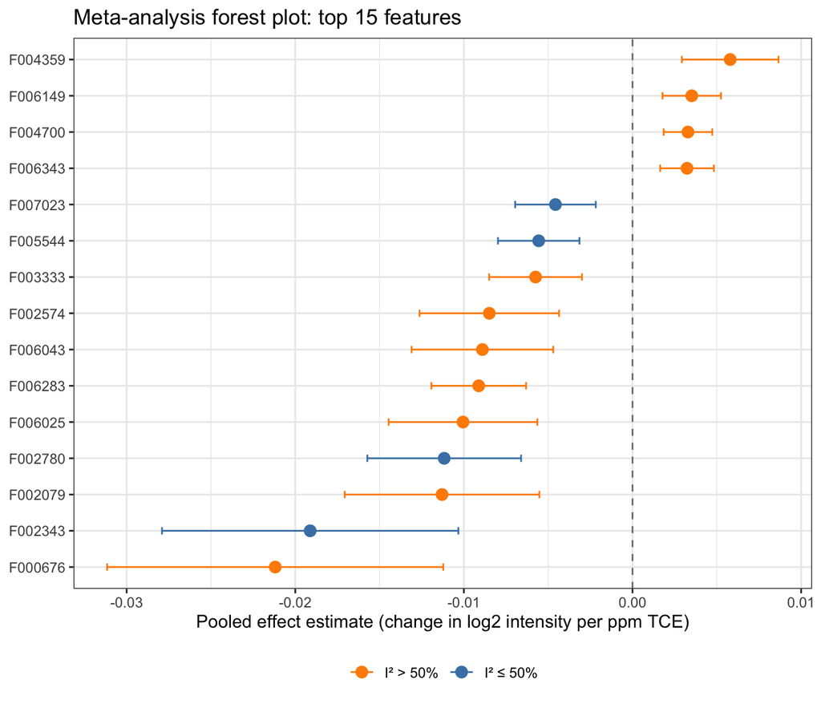

```r
top_meta <- head(meta_out$results[order(meta_out$results$P.value), ], 15)

top_meta$Feature <- factor(
  top_meta$CPG.Labels,
  levels = top_meta$CPG.Labels[order(top_meta$meta_effect)]
)
top_meta$heterogeneity <- ifelse(top_meta$I2 > 50, "I² > 50%", "I² ≤ 50%")

ggplot(top_meta, aes(x = meta_effect, y = Feature, color = heterogeneity)) +
  geom_vline(xintercept = 0, linetype = "dashed", color = "grey50") +
  geom_errorbar(
    aes(xmin = meta_effect - 1.96 * meta_se,
        xmax = meta_effect + 1.96 * meta_se),
    width = 0.2, orientation = "y"
  ) +
  geom_point(size = 3) +
  scale_color_manual(values = c("I² ≤ 50%" = "steelblue", "I² > 50%" = "darkorange")) +
  labs(
    x     = "Pooled effect estimate (change in log2 intensity per ppm TCE)",
    y     = NULL,
    color = NULL,
    title = "Meta-analysis forest plot: top 15 features"
  ) +
  theme_bw() +
  theme(legend.position = "bottom")
```